# hw1gizemkurtbayie582

gizemkurtbay

```r
#gizem kurtbay- code for hw 1 of ie582
```

```r
#install.packages("data.table")
#install.packages("anytime")
require(data.table)
require(anytime)
```

The data is taken from the location

```r
matches_file_path='C:/Users/Gizem/Downloads/ie582icin/df9b1196-e3cf-4cc7-9159-f236fe738215_matches.rds'
odd_details_file_path='C:/Users/Gizem/Downloads/ie582icin/df9b1196-e3cf-4cc7-9159-f236fe738215_odd_details.rds'

##TASK 1 A
```

TASK 1 a;

The goodness of the over/under decisions of 5 different bookmakers is checked in this task by using scatter plots. Aline with the equation of x=y is also plotted as a red line to give a better visualization to the plots. The data are expected to be around the x=y line if the bookmaker’s decisions are good. Initial and final odds are found and plotted against the results for all bookmakers.

The code required to prepare the data is written, the code is hidden since it is long and known.

```r
matches=readRDS(matches_file_path)

odds=readRDS(odd_details_file_path)

str(matches)
```

```
## Classes 'data.table' and 'data.frame':   3122 obs. of  7 variables:
##  $ leagueId: chr  "df9b1196-e3cf-4cc7-9159-f236fe738215" "df9b1196-e3cf-4cc7-9159-f236fe738215" "df9b1196-e3cf-4cc7-9159-f236fe738215" "df9b1196-e3cf-4cc7-9159-f236fe738215" ...
##  $ matchId : chr  "KjF6FiA6" "ILVbJgQm" "SGIEDVvJ" "YwL5xFHJ" ...
##  $ home    : chr  "tottenham" "aston villa" "wolves" "bolton" ...
##  $ away    : chr  "manchester city" "west ham" "stoke city" "fulham" ...
##  $ score   : chr  "0:0" "3:0" "2:1" "0:0" ...
##  $ date    : num  1.28e+09 1.28e+09 1.28e+09 1.28e+09 1.28e+09 ...
##  $ type    : chr  "soccer" "soccer" "soccer" "soccer" ...
##  - attr(*, ".internal.selfref")=<externalptr>
```

```r
matches=unique(matches)

zero_zero_matches=matches[score=='0:0']

#transform unix time to date
matches[,match_date:=anydate(date)]
#transform unix time to date time
matches[,match_time:=anytime(date)]

#order by home team and match date (decreasing)
matches=matches[order(home,-match_time)]

#only one column deletion
matches[,date:=NULL]

#only delete any number of columns
matches[,c("match_date","date"):=NULL]
#matches[,3,with=F]

matches[,c("HomeGoals","AwayGoals"):=tstrsplit(score,':')]

matches[,Year:=year(match_time)]
matches[,Month:=month(match_time)]
matches[,Weekday:=wday(match_time)]
matches[,Hour:=hour(match_time)]

#transform characters to numeric for scores
matches$HomeGoals=as.numeric(matches$HomeGoals)
matches[,AwayGoals:=as.numeric(AwayGoals)]

#calculate total goals
matches[,TotalGoals:=HomeGoals+AwayGoals]

# mark over under
matches[,IsOver:=0]
matches[TotalGoals>2,IsOver:=1]

#alternative
matches[,IsOverAlt:=as.numeric(TotalGoals>2)]

#filter na scores
matches[is.na(score)]
```

```
##                                leagueId  matchId        home
## 1: df9b1196-e3cf-4cc7-9159-f236fe738215 4tkXfsT9      fulham
## 2: df9b1196-e3cf-4cc7-9159-f236fe738215 zTB4xZCr   liverpool
## 3: df9b1196-e3cf-4cc7-9159-f236fe738215 Wf5DzDse southampton
##               away score   type          match_time HomeGoals AwayGoals
## 1:         arsenal  <NA> soccer 2018-10-07 15:00:00        NA        NA
## 2: manchester-city  <NA> soccer 2018-10-07 19:30:00        NA        NA
## 3:         chelsea  <NA> soccer 2018-10-07 17:15:00        NA        NA
##    Year Month Weekday Hour TotalGoals IsOver IsOverAlt
## 1: 2018    10       1   15         NA      0        NA
## 2: 2018    10       1   19         NA      0        NA
## 3: 2018    10       1   17         NA      0        NA
```

```r
#filter all NAs
matches=matches[complete.cases(matches)]

#yearly average goals
yearly_goals=matches[,list(AvgGoals=mean(TotalGoals)),by=list(Year)]

#yearly hourly average goals
yearly_hourly_goals=matches[,list(AvgGoals=mean(TotalGoals),
                                  MaxGoals=max(TotalGoals),
                                  NGames=.N, AltNGames=length(matchId)),
                            by=list(Year,Hour)]


#get the game with the max total goals
max_game=matches[,list(MaxGoals=max(TotalGoals),
                       homeMax=home[which.max(TotalGoals)],
                       awayMax=away[which.max(TotalGoals)]),
                 by=list(Year,Hour)]


#get the game with the max total goals for Year greater than 2017
max_game=matches[Year>2017,list(MaxGoals=max(TotalGoals),
                                homeMax=home[which.max(TotalGoals)],
                                awayMax=away[which.max(TotalGoals)]),
                 by=list(Year,Hour)]


#filter over under 2.5
odds_ov_un=odds[betType=='ou' & totalhandicap=='2.5']

#remove total handicap
odds_ov_un[,totalhandicap:=NULL]

#remove original odds data
#rm(odds); gc();

#order data in ascending date
odds_ov_un=odds_ov_un[order(matchId, oddtype,bookmaker,date)]

odds_ov_un_initial=odds_ov_un[,list(start_odd=odd[1]),
                              by=list(matchId,oddtype,bookmaker)]

odds_ov_un_final=odds_ov_un[,list(final_odd=odd[.N]),
                            by=list(matchId,oddtype,bookmaker)]


#transform to wide format
wide_odds_initial=dcast(odds_ov_un_initial,
                        matchId~oddtype+bookmaker,
                        value.var='start_odd')

#transform to long
long_ov_un_initial=melt(wide_odds_initial,id.vars=1,
                        measure.vars=2:ncol(wide_odds_initial))
```

The code for 5 bookmakers including pinnacle is written. The code for pinnacle is shown as below. The other bookmakers have the same code, so the code is hidden.

```r
## FOR 5 BOOKMAKERS!!!

##for pinnacle
#get pinnacle initial over under odds
pinnacle_over_under_initial=odds_ov_un_initial[bookmaker=='Pinnacle']

pinnacle_wide_initial=dcast (pinnacle_over_under_initial,
                             matchId~oddtype,
                             value.var='start_odd')


# join odds with matches for pinnacle
merged_matches_pinnacle_initial=merge(matches,pinnacle_wide_initial,by='matchId' )



merged_matches_pinnacle_initial[,probOver:=1/over]
merged_matches_pinnacle_initial[,probUnder:=1/under]

merged_matches_pinnacle_initial[,totalProb:=probOver+probUnder]

merged_matches_pinnacle_initial[,probOver:=probOver/totalProb]
merged_matches_pinnacle_initial[,probUnder:=probUnder/totalProb]

merged_matches_pinnacle_initial=merged_matches_pinnacle_initial[complete.cases(merged_matches_pinnacle_initial)]
merged_matches_pinnacle_initial[,totalProb:=NULL]

cutpoints=seq(0,1,0.05)
merged_matches_pinnacle_initial[,odd_cut_over:=cut(probOver,cutpoints)]

summary_table_pinnacle_initial=merged_matches_pinnacle_initial[,list(empirical_over_pinnacle=mean(IsOver),
                                                                     probabilistic_over_pinnacle=mean(probOver),.N),
                                                               by=list(Year,odd_cut_over)]

summary_table_pinnacle_initial=summary_table_pinnacle_initial[order(Year)]
```

Plot of empirical data versus the initial probabilities of Pinnacle is plotted in the figure below. As it can be seen from the figure, most of the data is around the x=y line which show that Pinnacle had good estimations about the results. There are outliers in the graph, however unexpected reasons may have affected the results of matches.

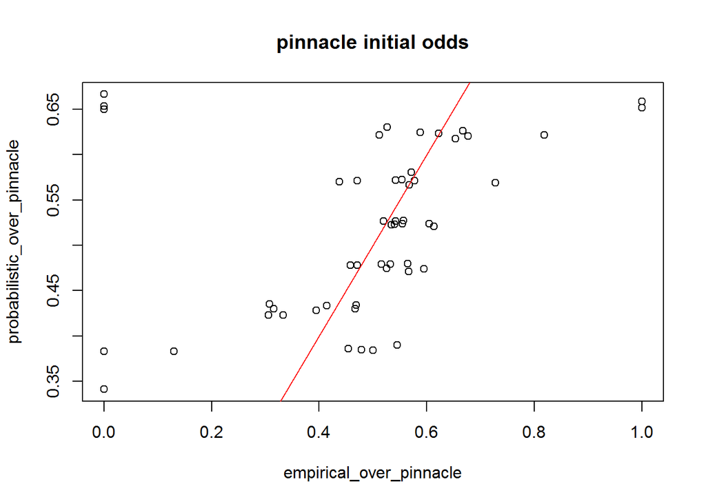

```r
plot(summary_table_pinnacle_initial[,list(empirical_over_pinnacle,probabilistic_over_pinnacle)],cex=1,main='pinnacle initial odds')
abline(0,1,col='red')
```

```r
#get pinnacle final over under odds
pinnacle_over_under_final=odds_ov_un_final[bookmaker=='Pinnacle']

pinnacle_wide_final=dcast (pinnacle_over_under_final,
                           matchId~oddtype,
                           value.var='final_odd')
```

```r
# join odds with matches for pinnacle
merged_matches_pinnacle_final=merge(matches,pinnacle_wide_final,by='matchId' )



merged_matches_pinnacle_final[,probOver:=1/over]
merged_matches_pinnacle_final[,probUnder:=1/under]

merged_matches_pinnacle_final[,totalProb:=probOver+probUnder]

merged_matches_pinnacle_final[,probOver:=probOver/totalProb]
merged_matches_pinnacle_final[,probUnder:=probUnder/totalProb]

merged_matches_pinnacle_final=merged_matches_pinnacle_final[complete.cases(merged_matches_pinnacle_final)]
merged_matches_pinnacle_final[,totalProb:=NULL]

cutpoints=seq(0,1,0.05)
merged_matches_pinnacle_final[,odd_cut_over:=cut(probOver,cutpoints)]

summary_table_pinnacle_final=merged_matches_pinnacle_final[,list(empirical_over_pinnacle=mean(IsOver),
                                                                 probabilistic_over_pinnacle=mean(probOver),.N),
                                                           by=list(Year,odd_cut_over)]

summary_table_pinnacle_final=summary_table_pinnacle_final[order(Year)]
```

Plot of empirical data versus the final probabilities of Pinnacle is plotted in the figure below. As it can be seen from the figure, most of the data is around the x=y line which show that Pinnacle had good estimations about the results. Moreover, the data points are closer to x=y line compared to the initial probabilities plot, which shows that the estimations got better through the time before the results are obtained. There are outliers in the graph, however unexpected reasons may have affected the results of matches even during the match time.

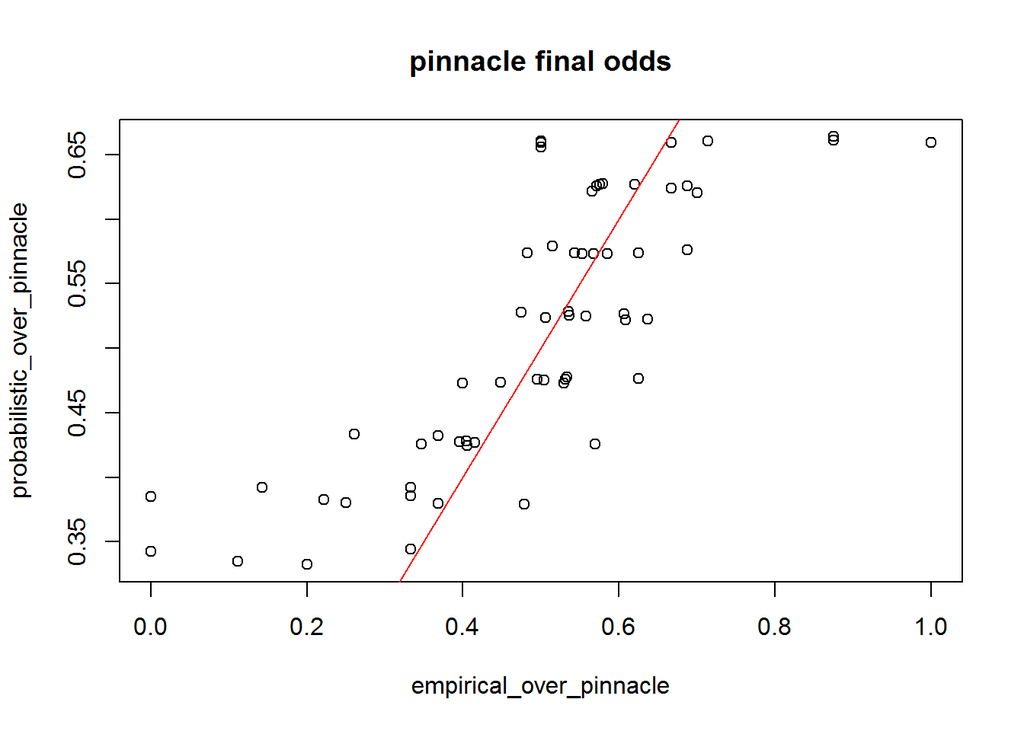

```r
plot(summary_table_pinnacle_final[,list(empirical_over_pinnacle,probabilistic_over_pinnacle)],cex=1,main='pinnacle final odds')
abline(0,1,col='red')
```

```r
##for bet365

#get bet365 initial over under odds
bet365_over_under_initial=odds_ov_un_initial[bookmaker=='bet365']

bet365_wide_initial=dcast (bet365_over_under_initial,
                           matchId~oddtype,
                           value.var='start_odd')


# join odds with matches for bet365
merged_matches_bet365_initial=merge(matches,bet365_wide_initial,by='matchId' )



merged_matches_bet365_initial[,probOver:=1/over]
merged_matches_bet365_initial[,probUnder:=1/under]

merged_matches_bet365_initial[,totalProb:=probOver+probUnder]

merged_matches_bet365_initial[,probOver:=probOver/totalProb]
merged_matches_bet365_initial[,probUnder:=probUnder/totalProb]

merged_matches_bet365_initial=merged_matches_bet365_initial[complete.cases(merged_matches_bet365_initial)]
merged_matches_bet365_initial[,totalProb:=NULL]

cutpoints=seq(0,1,0.05)
merged_matches_bet365_initial[,odd_cut_over:=cut(probOver,cutpoints)]

summary_table_bet365_initial=merged_matches_bet365_initial[,list(empirical_over_bet365=mean(IsOver),
                                                                 probabilistic_over_bet365=mean(probOver),.N),
                                                           by=list(Year,odd_cut_over)]

summary_table_bet365_initial=summary_table_bet365_initial[order(Year)]
```

Plot of empirical data versus the initial probabilities of bet365 is plotted in the figure below. As it can be seen from the figure, most of the data is around the x=y line which show that bet365 had good estimations about the results. There are outliers in the graph, however unexpected reasons may have affected the results of matches, and the number of outliers is less than the number of outliers of Pinnacle’s, which shows bet365 may be more stable in case of unexpected situations. However, when we check the data points around the x=y line, the data of bet365 is spread wider compared to the data of Pinnacle. It can be observed that Pinnacle may guess closer to real results generally, however bet365 is more robust for unexpected reasons to cause outliers.

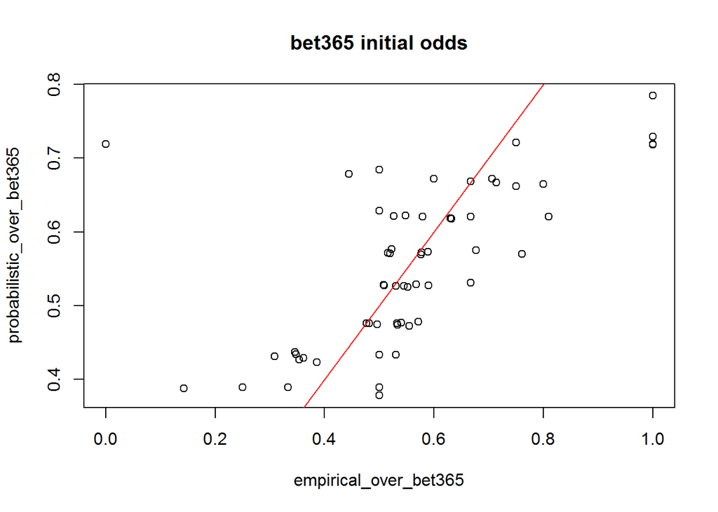

```r
plot(summary_table_bet365_initial[,list(empirical_over_bet365,probabilistic_over_bet365)],cex=1,main='bet365 initial odds')
abline(0,1,col='red')
```

```r
#get bet365 final over under odds
bet365_over_under_final=odds_ov_un_final[bookmaker=='bet365']

bet365_wide_final=dcast (bet365_over_under_final,
                         matchId~oddtype,
                         value.var='final_odd')


# join odds with matches for bet365
merged_matches_bet365_final=merge(matches,bet365_wide_final,by='matchId' )



merged_matches_bet365_final[,probOver:=1/over]
merged_matches_bet365_final[,probUnder:=1/under]

merged_matches_bet365_final[,totalProb:=probOver+probUnder]

merged_matches_bet365_final[,probOver:=probOver/totalProb]
merged_matches_bet365_final[,probUnder:=probUnder/totalProb]

merged_matches_bet365_final=merged_matches_bet365_final[complete.cases(merged_matches_bet365_final)]
merged_matches_bet365_final[,totalProb:=NULL]

cutpoints=seq(0,1,0.05)
merged_matches_bet365_final[,odd_cut_over:=cut(probOver,cutpoints)]

summary_table_bet365_final=merged_matches_bet365_final[,list(empirical_over_bet365=mean(IsOver),
                                                             probabilistic_over_bet365=mean(probOver),.N),
                                                       by=list(Year,odd_cut_over)]

summary_table_bet365_final=summary_table_bet365_final[order(Year)]
```

Plot of empirical data versus the final probabilities of bet 365 is plotted in the figure below. As it can be seen from the figure, most of the data is around the x=y line which show that bet365 had good estimations about the results. Locations of some of the data points changed around x=y line compared to the initial probabilities plot, and it can be seen that the data points are more homogeneous around the x=y plot. Initially the number of data points below x=y was higher compared to the number above the x=y line, and the numbers got closer to each other as time passed. There are some outliers in the graph, however unexpected reasons may have affected the results of matches even during the match time.

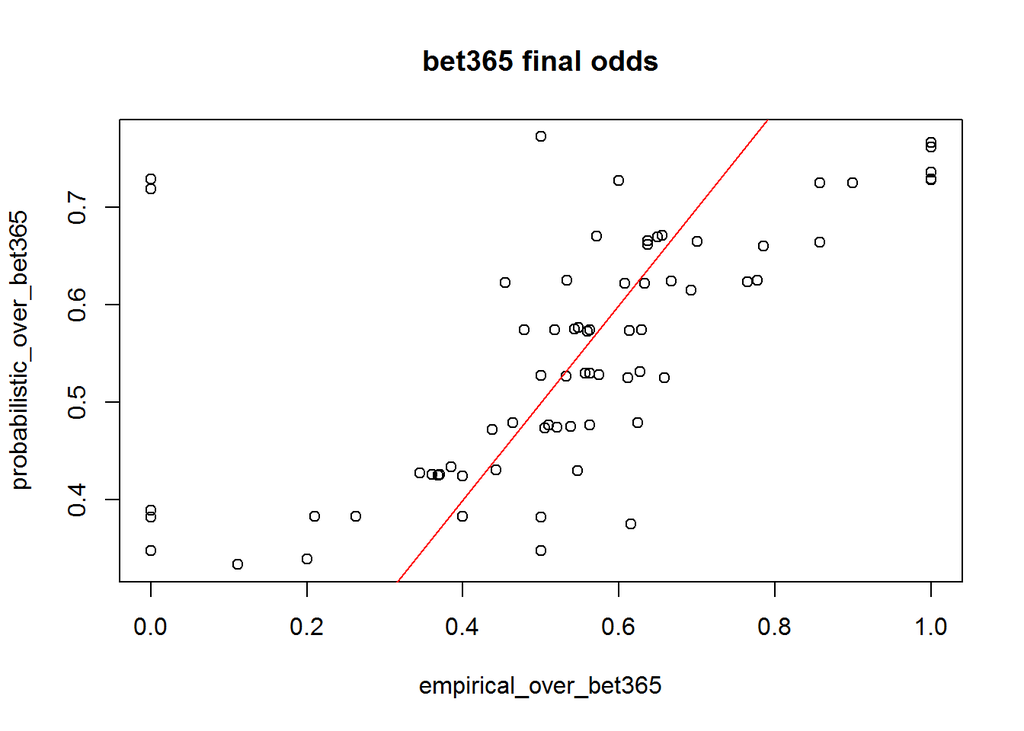

```r
plot(summary_table_bet365_final[,list(empirical_over_bet365,probabilistic_over_bet365)],cex=1,main='bet365 final odds')
abline(0,1,col='red')
```

```r
##for Betway

#get Betway initial over under odds
Betway_over_under_initial=odds_ov_un_initial[bookmaker=='Betway']

Betway_wide_initial=dcast (Betway_over_under_initial,
                           matchId~oddtype,
                           value.var='start_odd')


# join odds with matches for Betway
merged_matches_Betway_initial=merge(matches,Betway_wide_initial,by='matchId' )



merged_matches_Betway_initial[,probOver:=1/over]
merged_matches_Betway_initial[,probUnder:=1/under]

merged_matches_Betway_initial[,totalProb:=probOver+probUnder]

merged_matches_Betway_initial[,probOver:=probOver/totalProb]
merged_matches_Betway_initial[,probUnder:=probUnder/totalProb]

merged_matches_Betway_initial=merged_matches_Betway_initial[complete.cases(merged_matches_Betway_initial)]
merged_matches_Betway_initial[,totalProb:=NULL]

cutpoints=seq(0,1,0.05)
merged_matches_Betway_initial[,odd_cut_over:=cut(probOver,cutpoints)]

summary_table_Betway_initial=merged_matches_Betway_initial[,list(empirical_over_Betway=mean(IsOver),
                                                                 probabilistic_over_Betway=mean(probOver),.N),
                                                           by=list(Year,odd_cut_over)]

summary_table_Betway_initial=summary_table_Betway_initial[order(Year)]
```

Plot of empirical data versus the initial probabilities of betway is plotted in the figure below. As it can be seen from the figure, most of the data is around the x=y line which show that betway had good estimations about the results. There are outliers in the graph, however unexpected reasons may have affected the results of matches.

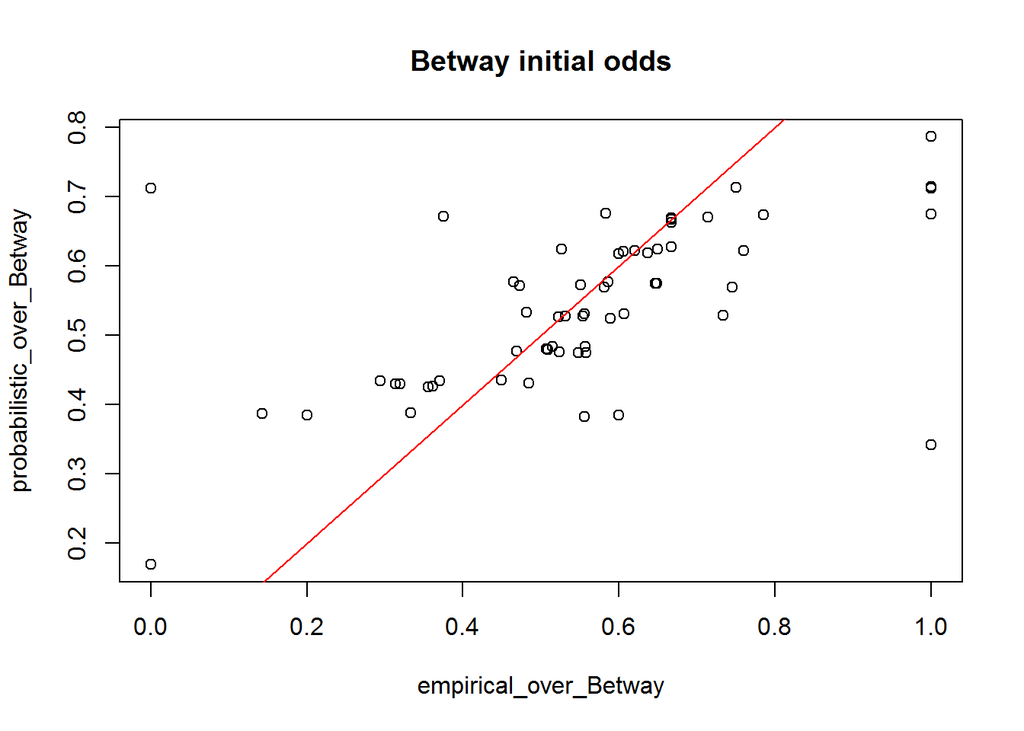

```r
plot(summary_table_Betway_initial[,list(empirical_over_Betway,probabilistic_over_Betway)],cex=1,main='Betway initial odds')
abline(0,1,col='red')
```

```r
#get Betway final over under odds
Betway_over_under_final=odds_ov_un_final[bookmaker=='Betway']

Betway_wide_final=dcast (Betway_over_under_final,
                         matchId~oddtype,
                         value.var='final_odd')


# join odds with matches for Betway
merged_matches_Betway_final=merge(matches,Betway_wide_final,by='matchId' )



merged_matches_Betway_final[,probOver:=1/over]
merged_matches_Betway_final[,probUnder:=1/under]

merged_matches_Betway_final[,totalProb:=probOver+probUnder]

merged_matches_Betway_final[,probOver:=probOver/totalProb]
merged_matches_Betway_final[,probUnder:=probUnder/totalProb]

merged_matches_Betway_final=merged_matches_Betway_final[complete.cases(merged_matches_Betway_final)]
merged_matches_Betway_final[,totalProb:=NULL]

cutpoints=seq(0,1,0.05)
merged_matches_Betway_final[,odd_cut_over:=cut(probOver,cutpoints)]

summary_table_Betway_final=merged_matches_Betway_final[,list(empirical_over_Betway=mean(IsOver),
                                                             probabilistic_over_Betway=mean(probOver),.N),
                                                       by=list(Year,odd_cut_over)]

summary_table_Betway_final=summary_table_Betway_final[order(Year)]
```

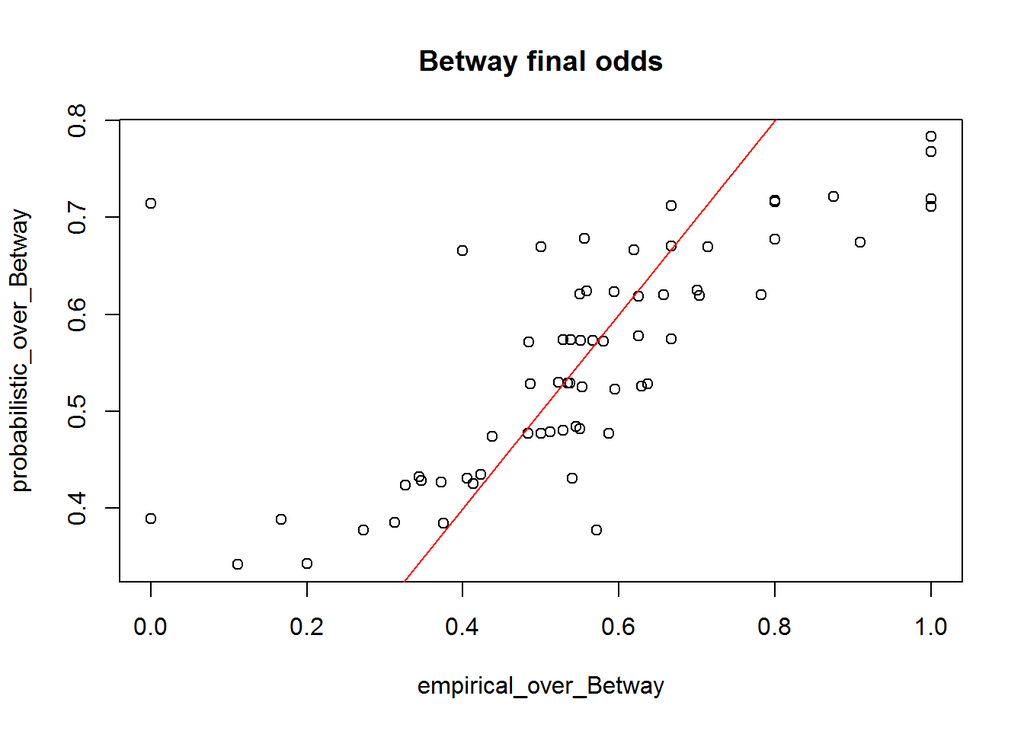

```r
plot(summary_table_Betway_final[,list(empirical_over_Betway,probabilistic_over_Betway)],cex=1,main='Betway final odds')
abline(0,1,col='red')
```

```r
##for bwin

#get bwin initial over under odds
bwin_over_under_initial=odds_ov_un_initial[bookmaker=='bwin']

bwin_wide_initial=dcast (bwin_over_under_initial,
                         matchId~oddtype,
                         value.var='start_odd')


# join odds with matches for bwin
merged_matches_bwin_initial=merge(matches,bwin_wide_initial,by='matchId' )



merged_matches_bwin_initial[,probOver:=1/over]
merged_matches_bwin_initial[,probUnder:=1/under]

merged_matches_bwin_initial[,totalProb:=probOver+probUnder]

merged_matches_bwin_initial[,probOver:=probOver/totalProb]
merged_matches_bwin_initial[,probUnder:=probUnder/totalProb]

merged_matches_bwin_initial=merged_matches_bwin_initial[complete.cases(merged_matches_bwin_initial)]
merged_matches_bwin_initial[,totalProb:=NULL]

cutpoints=seq(0,1,0.05)
merged_matches_bwin_initial[,odd_cut_over:=cut(probOver,cutpoints)]

summary_table_bwin_initial=merged_matches_bwin_initial[,list(empirical_over_bwin=mean(IsOver),
                                                             probabilistic_over_bwin=mean(probOver),.N),
                                                       by=list(Year,odd_cut_over)]

summary_table_bwin_initial=summary_table_bwin_initial[order(Year)]
```

Plot of empirical data versus the initial probabilities of bwin is plotted in the figure below. As it can be seen from the figure, most of the data is around the x=y line which show that bwin had good estimations about the results. There are some outliers in the graph, however unexpected reasons may have affected the results of matches.

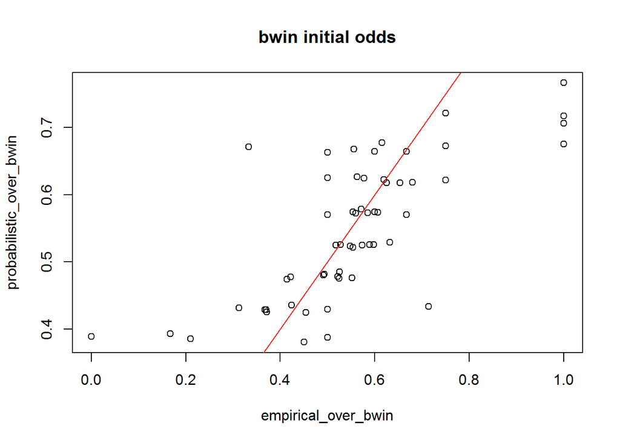

```r
plot(summary_table_bwin_initial[,list(empirical_over_bwin,probabilistic_over_bwin)],cex=1,main='bwin initial odds')
abline(0,1,col='red')
```

```r
#get bwin final over under odds
bwin_over_under_final=odds_ov_un_final[bookmaker=='bwin']

bwin_wide_final=dcast (bwin_over_under_final,
                       matchId~oddtype,
                       value.var='final_odd')


# join odds with matches for bwin
merged_matches_bwin_final=merge(matches,bwin_wide_final,by='matchId' )



merged_matches_bwin_final[,probOver:=1/over]
merged_matches_bwin_final[,probUnder:=1/under]

merged_matches_bwin_final[,totalProb:=probOver+probUnder]

merged_matches_bwin_final[,probOver:=probOver/totalProb]
merged_matches_bwin_final[,probUnder:=probUnder/totalProb]

merged_matches_bwin_final=merged_matches_bwin_final[complete.cases(merged_matches_bwin_final)]
merged_matches_bwin_final[,totalProb:=NULL]

cutpoints=seq(0,1,0.05)
merged_matches_bwin_final[,odd_cut_over:=cut(probOver,cutpoints)]

summary_table_bwin_final=merged_matches_bwin_final[,list(empirical_over_bwin=mean(IsOver),
                                                         probabilistic_over_bwin=mean(probOver),.N),
                                                   by=list(Year,odd_cut_over)]

summary_table_bwin_final=summary_table_bwin_final[order(Year)]
```

Plot of empirical data versus the final probabilities of bwin is plotted in the figure below. As it can be seen from the figure, most of the data is around the x=y line which show that bwin had good estimations about the results. Locations of some of the data points changed around x=y line compared to the initial probabilities plot, and it can be seen that the data points are more homogeneous around the x=y plot. Initially the number of data points below x=y was higher compared to the number above the x=y line, and the numbers got closer to each other as time passed similar to the observation of bet365. There are some outliers in the graph, however unexpected reasons may have affected the results of matches even during the match time.

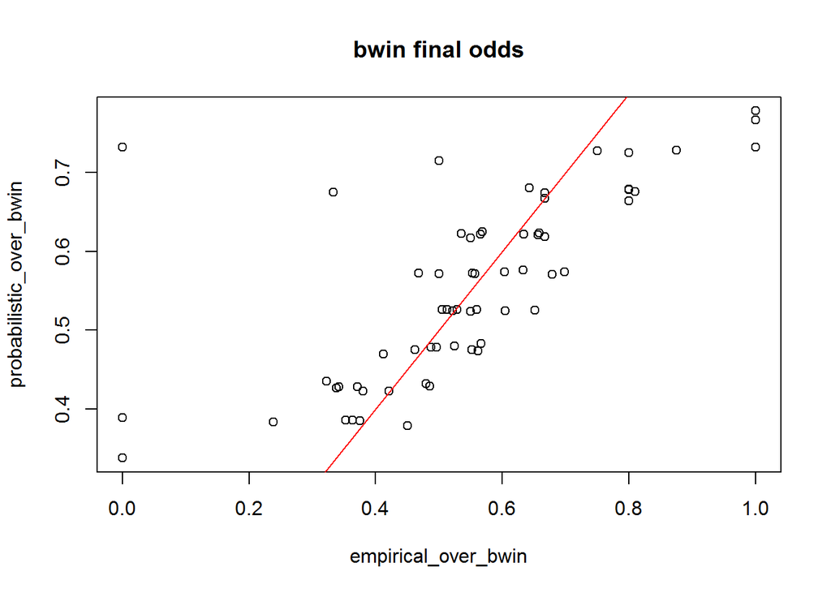

```r
plot(summary_table_bwin_final[,list(empirical_over_bwin,probabilistic_over_bwin)],cex=1,main='bwin final odds')
abline(0,1,col='red')
```

```r
##for Betsson

#get Betsson initial over under odds
Betsson_over_under_initial=odds_ov_un_initial[bookmaker=='Betsson']

Betsson_wide_initial=dcast (Betsson_over_under_initial,
                            matchId~oddtype,
                            value.var='start_odd')


# join odds with matches for Betsson
merged_matches_Betsson_initial=merge(matches,Betsson_wide_initial,by='matchId' )



merged_matches_Betsson_initial[,probOver:=1/over]
merged_matches_Betsson_initial[,probUnder:=1/under]

merged_matches_Betsson_initial[,totalProb:=probOver+probUnder]

merged_matches_Betsson_initial[,probOver:=probOver/totalProb]
merged_matches_Betsson_initial[,probUnder:=probUnder/totalProb]

merged_matches_Betsson_initial=merged_matches_Betsson_initial[complete.cases(merged_matches_Betsson_initial)]
merged_matches_Betsson_initial[,totalProb:=NULL]

cutpoints=seq(0,1,0.05)
merged_matches_Betsson_initial[,odd_cut_over:=cut(probOver,cutpoints)]

summary_table_Betsson_initial=merged_matches_Betsson_initial[,list(empirical_over_Betsson=mean(IsOver),
                                                                   probabilistic_over_Betsson=mean(probOver),.N),
                                                             by=list(Year,odd_cut_over)]

summary_table_Betsson_initial=summary_table_Betsson_initial[order(Year)]
```

Plot of empirical data versus the initial probabilities of betsson is plotted in the figure below. As it can be seen from the figure, most of the data is around the x=y line which show that betsson had good estimations about the results. There are some outliers in the graph, however unexpected reasons may have affected the results of matches. The outliers are mostly around the empirical values of 0.00 and 1.0.

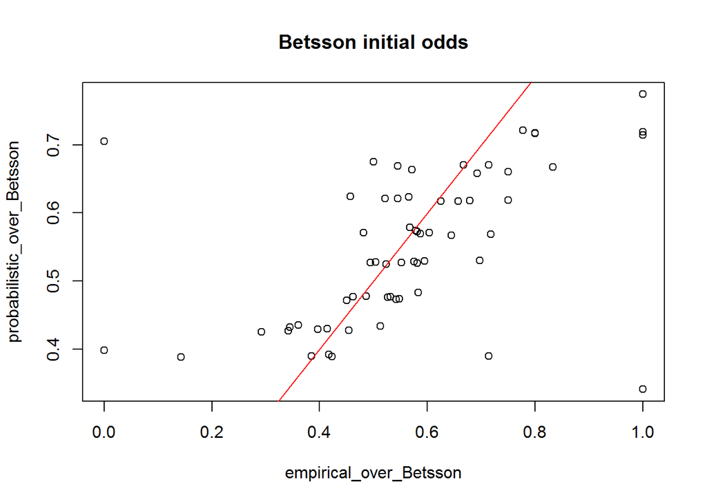

```r
plot(summary_table_Betsson_initial[,list(empirical_over_Betsson,probabilistic_over_Betsson)],cex=1,main='Betsson initial odds')
abline(0,1,col='red')
```

Plot of empirical data versus the final probabilities of betsson is plotted in the figure below. As it can be seen from the figure, most of the data is around the x=y line which show that betsson had good estimations about the results. Locations of some of the data points changed around x=y line compared to the initial probabilities plot, and it can be seen that the data points are more homogeneous around the x=y plot. Initially the number of data points below x=y was higher compared to the number above the x=y line, and the numbers got closer to each other as time passed similar to the observation of bet365 and bwin. There are some outliers in the graph, however unexpected reasons may have affected the results of matches even during the match time.

```r
#get Betsson final over under odds
Betsson_over_under_final=odds_ov_un_final[bookmaker=='Betsson']

Betsson_wide_final=dcast (Betsson_over_under_final,
                          matchId~oddtype,
                          value.var='final_odd')


# join odds with matches for Betsson
merged_matches_Betsson_final=merge(matches,Betsson_wide_final,by='matchId' )



merged_matches_Betsson_final[,probOver:=1/over]
merged_matches_Betsson_final[,probUnder:=1/under]

merged_matches_Betsson_final[,totalProb:=probOver+probUnder]

merged_matches_Betsson_final[,probOver:=probOver/totalProb]
merged_matches_Betsson_final[,probUnder:=probUnder/totalProb]

merged_matches_Betsson_final=merged_matches_Betsson_final[complete.cases(merged_matches_Betsson_final)]
merged_matches_Betsson_final[,totalProb:=NULL]

cutpoints=seq(0,1,0.05)
merged_matches_Betsson_final[,odd_cut_over:=cut(probOver,cutpoints)]

summary_table_Betsson_final=merged_matches_Betsson_final[,list(empirical_over_Betsson=mean(IsOver),
                                                               probabilistic_over_Betsson=mean(probOver),.N),
                                                         by=list(Year,odd_cut_over)]

summary_table_Betsson_final=summary_table_Betsson_final[order(Year)]
```

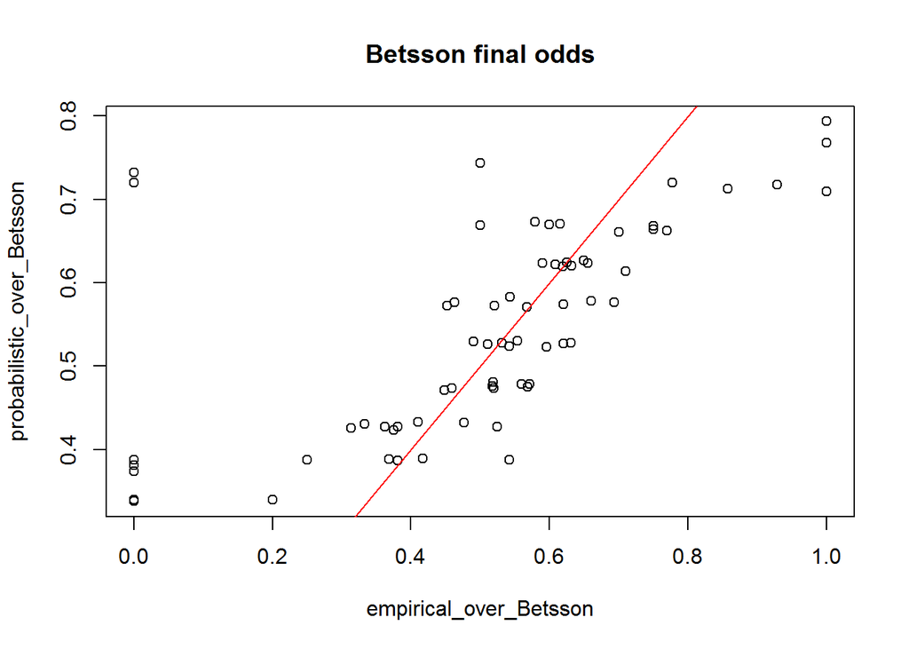

```r
plot(summary_table_Betsson_final[,list(empirical_over_Betsson,probabilistic_over_Betsson)],cex=1,main='Betsson final odds')
abline(0,1,col='red')
```

Task 1 b

```r
## TASK 1 B
```

```r
#Pinnacle is selected as the bookmaker for task1b
```

The code for all bins are shown, since all of them have plots.

It can be seen that, for the bin interval of 0.30 to 0.35 of final odds comparison, probabilities stay constant around the value of 0.35 while the empirical data fluctuates between 0 and 0.35. Expected probabilities are smoother than real results.

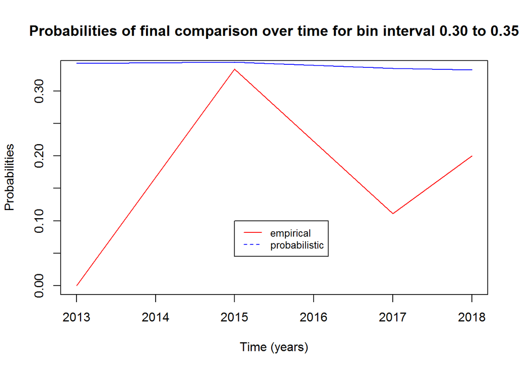

```r
#bin = 0.30 to 0.35  -  final

merged_matches_30_35_final=merged_matches_pinnacle_final[odd_cut_over=="(0.3,0.35]"]
merged_matches_30_35_final=merged_matches_30_35_final[,list(empirical_over=mean(IsOver),
                                                            probabilistic_over=mean(probOver),.N),by=list(Year)]
merged_matches_30_35_final=merged_matches_30_35_final[order(Year)]

plot(merged_matches_30_35_final$Year,merged_matches_30_35_final$empirical_over,type = "l",col="red",xlab="Time (years)",ylab="Probabilities"
     ,main='Probabilities of final comparison over time for bin interval 0.30 to 0.35')
lines(merged_matches_30_35_final$Year,merged_matches_30_35_final$probabilistic_over,col="blue")
legend(2015,0.10, legend=c("empirical", "probabilistic"), col=c("red", "blue"), lty=1:2, cex=0.8)
```

It can be seen that, for the bin interval of 0.35 to 0.40 of initial odds comparison, probabilities stay constant around the value of 0.4 while the empirical data fluctuates between 0 and 0.55. Expected probabilities are smoother than real results. There are empirical values both above and below the probabilistic values.

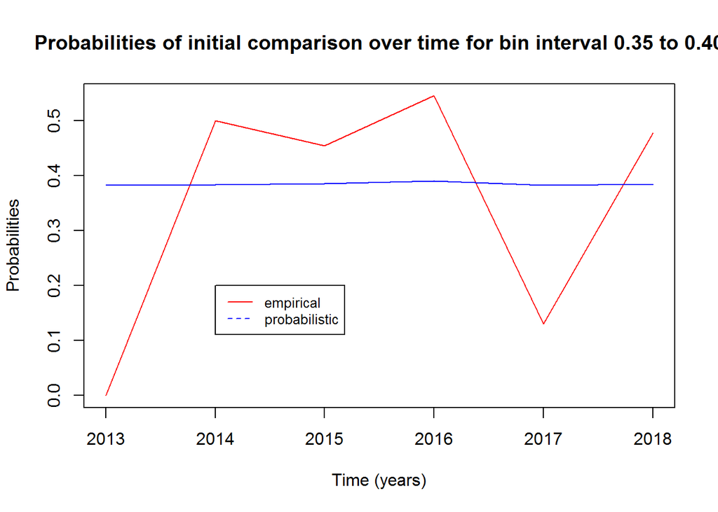

```r
#bin = 0.35 to 0.40  -  initial

merged_matches_35_40_initial=merged_matches_pinnacle_initial[odd_cut_over=="(0.35,0.4]"]
merged_matches_35_40_initial=merged_matches_35_40_initial[,list(empirical_over=mean(IsOver),
                                                                probabilistic_over=mean(probOver),.N),by=list(Year)]
merged_matches_35_40_initial=merged_matches_35_40_initial[order(Year)]

plot(merged_matches_35_40_initial$Year,merged_matches_35_40_initial$empirical_over,type = "l",col="red",xlab="Time (years)",ylab="Probabilities"
     ,main='Probabilities of initial comparison over time for bin interval 0.35 to 0.40')
lines(merged_matches_35_40_initial$Year,merged_matches_35_40_initial$probabilistic_over,col="blue")
legend(2014,0.20, legend=c("empirical", "probabilistic"), col=c("red", "blue"), lty=1:2, cex=0.8)
```

It can be seen that, for the bin interval of 0.35 to 0.40 of final odds comparison, probabilities stay constant around the value of 0.4 while the empirical data fluctuates between 0 and 0.45. Expected probabilities are smoother than real results. There were empirical values both above and below the probabilistic values initially, however in final time, the empirical values are mostly below probabilistic values, which shows a possible effect of time on probabilities.

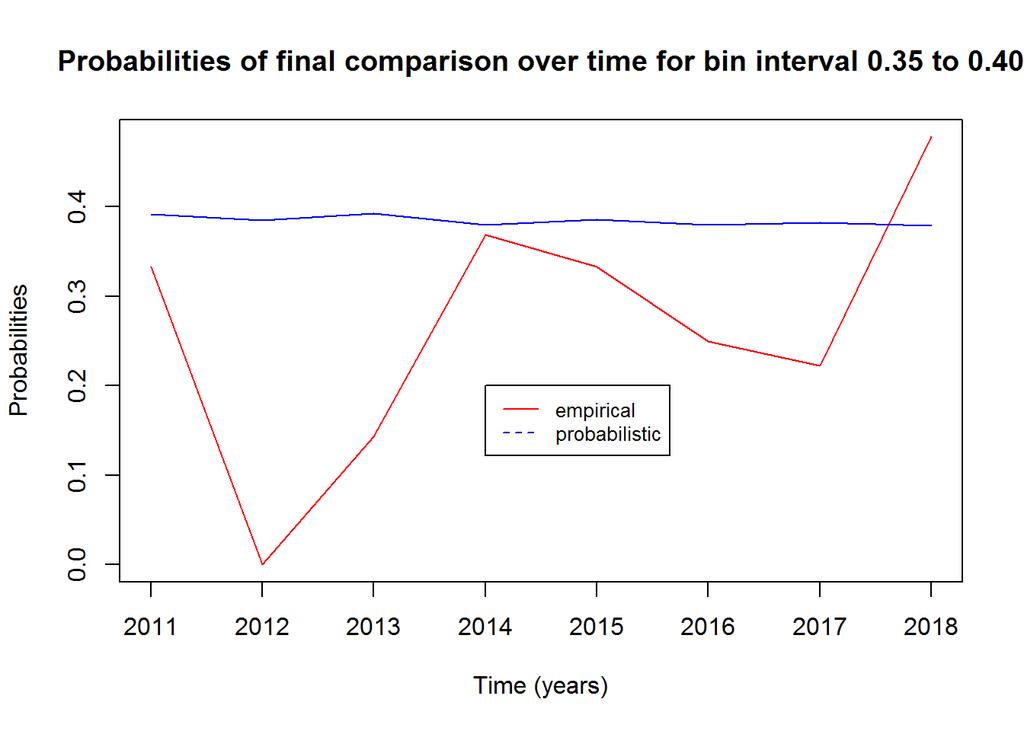

```r
#bin = 0.35 to 0.40  -  final

merged_matches_35_40_final=merged_matches_pinnacle_final[odd_cut_over=="(0.35,0.4]"]
merged_matches_35_40_final=merged_matches_35_40_final[,list(empirical_over=mean(IsOver),
                                                            probabilistic_over=mean(probOver),.N),by=list(Year)]
merged_matches_35_40_final=merged_matches_35_40_final[order(Year)]

plot(merged_matches_35_40_final$Year,merged_matches_35_40_final$empirical_over,type = "l",col="red",xlab="Time (years)",ylab="Probabilities"
     ,main='Probabilities of final comparison over time for bin interval 0.35 to 0.40')
lines(merged_matches_35_40_final$Year,merged_matches_35_40_final$probabilistic_over,col="blue")
legend(2014,0.20, legend=c("empirical", "probabilistic"), col=c("red", "blue"), lty=1:2, cex=0.8)
```

It can be seen that, for the bin interval of 0.4 to 0.45 of initial odds comparison, probabilities stay constant around the value of 0.44 while the empirical data fluctuates between 0.30 and 0.50. Expected probabilities are smoother than real results. There are empirical values both above and below the probabilistic values, but they are mostly below the probabilistic line.

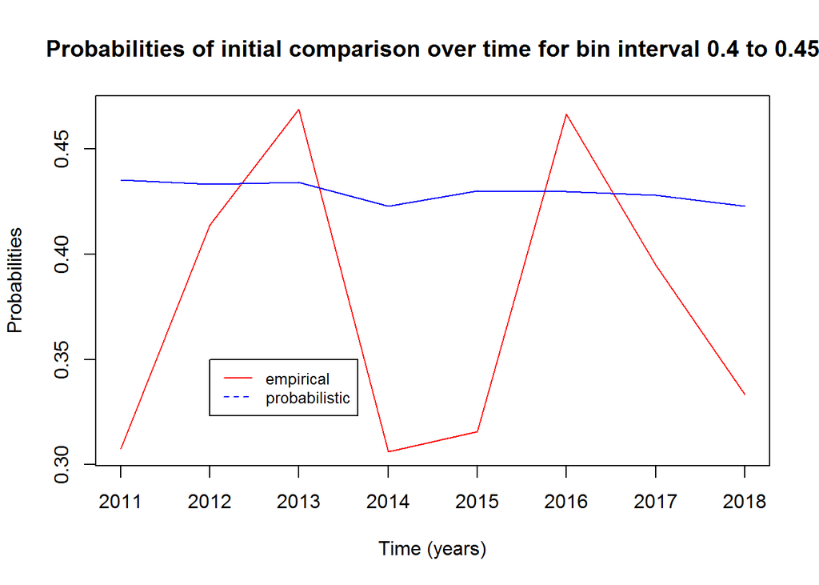

```r
#bin = 0.40 to 0.45  -  initial

merged_matches_40_45_initial=merged_matches_pinnacle_initial[odd_cut_over=="(0.4,0.45]"]
merged_matches_40_45_initial=merged_matches_40_45_initial[,list(empirical_over=mean(IsOver),
                                                                probabilistic_over=mean(probOver),.N),by=list(Year)]
merged_matches_40_45_initial=merged_matches_40_45_initial[order(Year)]

plot(merged_matches_40_45_initial$Year,merged_matches_40_45_initial$empirical_over,type = "l",col="red",xlab="Time (years)",ylab="Probabilities"
     ,main='Probabilities of initial comparison over time for bin interval 0.4 to 0.45')
lines(merged_matches_40_45_initial$Year,merged_matches_40_45_initial$probabilistic_over,col="blue")
legend(2012,0.35, legend=c("empirical", "probabilistic"), col=c("red", "blue"), lty=1:2, cex=0.8)
```

It can be seen that, for the bin interval of 0.40 to 0.45 of final odds comparison, probabilities stay constant around the value of 0.44 while the empirical data fluctuates between 0.25 and 0.55, however the empirical line got smoother compared to initial plot which shows that the estimations got better with time. However, still expected probabilities are smoother than real results.

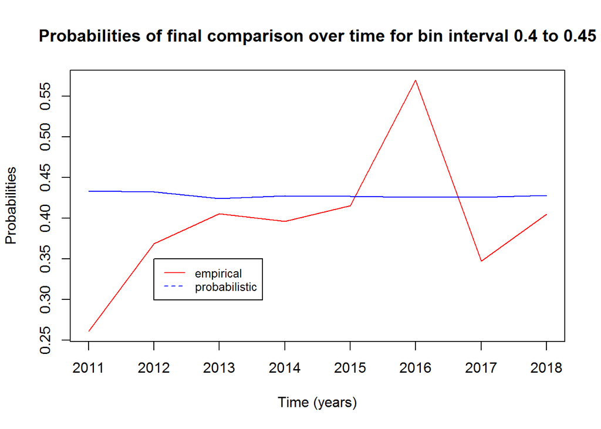

```r
#bin = 0.40 to 0.45  -  final

merged_matches_40_45_final=merged_matches_pinnacle_final[odd_cut_over=="(0.4,0.45]"]
merged_matches_40_45_final=merged_matches_40_45_final[,list(empirical_over=mean(IsOver),
                                                            probabilistic_over=mean(probOver),.N),by=list(Year)]
merged_matches_40_45_final=merged_matches_40_45_final[order(Year)]

plot(merged_matches_40_45_final$Year,merged_matches_40_45_final$empirical_over,type = "l",col="red",xlab="Time (years)",ylab="Probabilities"
     ,main='Probabilities of final comparison over time for bin interval 0.4 to 0.45')
lines(merged_matches_40_45_final$Year,merged_matches_40_45_final$probabilistic_over,col="blue")
legend(2012,0.35, legend=c("empirical", "probabilistic"), col=c("red", "blue"), lty=1:2, cex=0.8)
```

It can be seen that, for the bin interval of 0.45 to 0.50 of initial odds comparison, probabilities stay constant around the value of 0.48 to 0.46 while the empirical data fluctuates between 0.45 and 0.60. Expected probabilities are smoother than real results. There are empirical values both above and below the probabilistic values, but they are mostly above the probabilistic line and there are a lot of fluctuations.

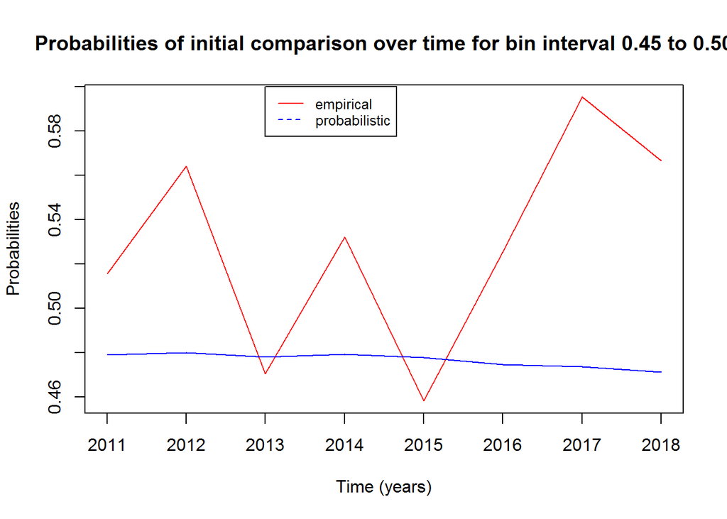

```r
#bin = 0.45 to 0.50  -  initial

merged_matches_45_50_initial=merged_matches_pinnacle_initial[odd_cut_over=="(0.45,0.5]"]
merged_matches_45_50_initial=merged_matches_45_50_initial[,list(empirical_over=mean(IsOver),
                                                                probabilistic_over=mean(probOver),.N),by=list(Year)]
merged_matches_45_50_initial=merged_matches_45_50_initial[order(Year)]

plot(merged_matches_45_50_initial$Year,merged_matches_45_50_initial$empirical_over,type = "l",col="red",xlab="Time (years)",ylab="Probabilities"
     ,main='Probabilities of initial comparison over time for bin interval 0.45 to 0.50')
lines(merged_matches_45_50_initial$Year,merged_matches_45_50_initial$probabilistic_over,col="blue")
legend(2013,0.60, legend=c("empirical", "probabilistic"), col=c("red", "blue"), lty=1:2, cex=0.8)
```

It can be seen that, for the bin interval of 0.45 to 0.50 of final odds comparison, probabilities stay constant around the value of 0.47 while the empirical data fluctuates between 0.40 and 0.65. Expected probabilities are smoother than real results. The empirical are still mostly above probabilistic values, but it is smoother, which shows a possible effect of time on probabilities.

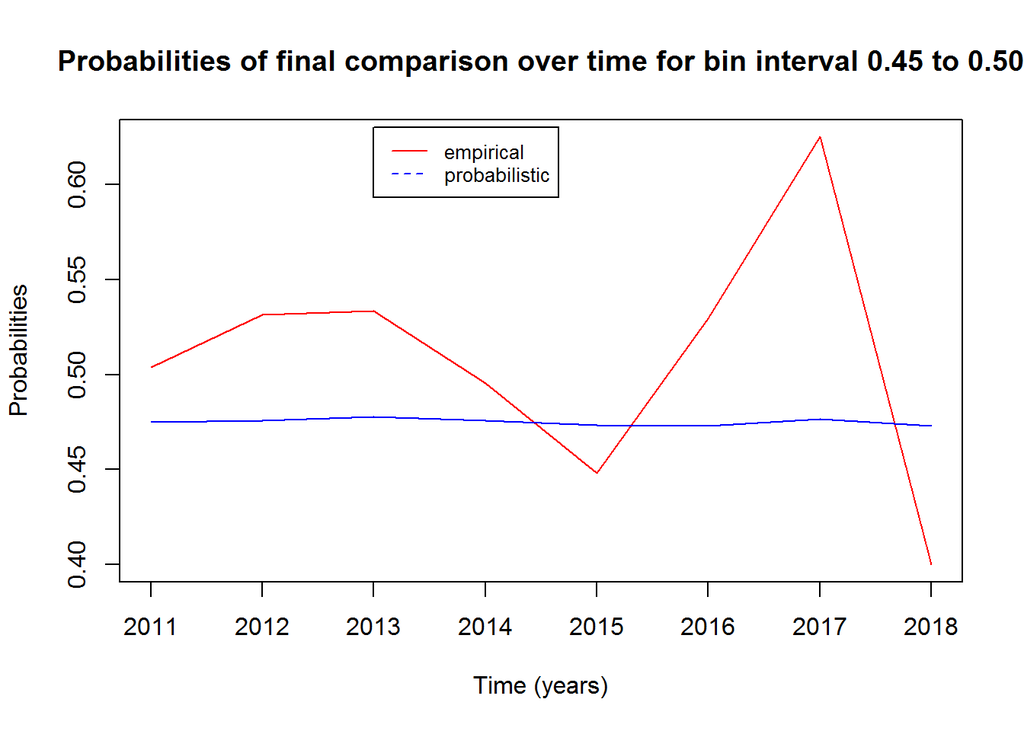

```r
#bin = 0.45 to 0.50  -  final

merged_matches_45_50_final=merged_matches_pinnacle_final[odd_cut_over=="(0.45,0.5]"]
merged_matches_45_50_final=merged_matches_45_50_final[,list(empirical_over=mean(IsOver),
                                                            probabilistic_over=mean(probOver),.N),by=list(Year)]
merged_matches_45_50_final=merged_matches_45_50_final[order(Year)]

plot(merged_matches_45_50_final$Year,merged_matches_45_50_final$empirical_over,type = "l",col="red",xlab="Time (years)",ylab="Probabilities"
     ,main='Probabilities of final comparison over time for bin interval 0.45 to 0.50')
lines(merged_matches_45_50_final$Year,merged_matches_45_50_final$probabilistic_over,col="blue")
legend(2013,0.63, legend=c("empirical", "probabilistic"), col=c("red", "blue"), lty=1:2, cex=0.8)
```

It can be seen that, for the bin interval of 0.50 to 0.55 of initial odds comparison, probabilities stay constant around the value of 0.50 to 0.52 while the empirical data fluctuates between 0.52 and 0.62. Expected probabilities are smoother than real results. There are empirical values both above and below the probabilistic values, but they are mostly above the probabilistic line.

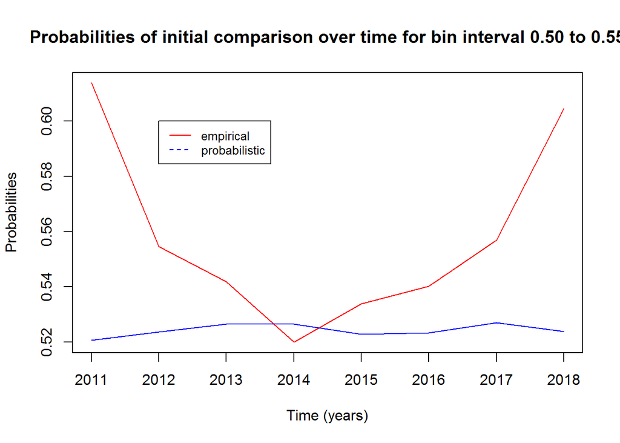

```r
#bin = 0.50 to 0.55  -  initial

merged_matches_50_55_initial=merged_matches_pinnacle_initial[odd_cut_over=="(0.5,0.55]"]
merged_matches_50_55_initial=merged_matches_50_55_initial[,list(empirical_over=mean(IsOver),
                                                                probabilistic_over=mean(probOver),.N),by=list(Year)]
merged_matches_50_55_initial=merged_matches_50_55_initial[order(Year)]

plot(merged_matches_50_55_initial$Year,merged_matches_50_55_initial$empirical_over,type = "l",col="red",xlab="Time (years)",ylab="Probabilities"
     ,main='Probabilities of initial comparison over time for bin interval 0.50 to 0.55')
lines(merged_matches_50_55_initial$Year,merged_matches_50_55_initial$probabilistic_over,col="blue")
legend(2012,0.60, legend=c("empirical", "probabilistic"), col=c("red", "blue"), lty=1:2, cex=0.8)
```

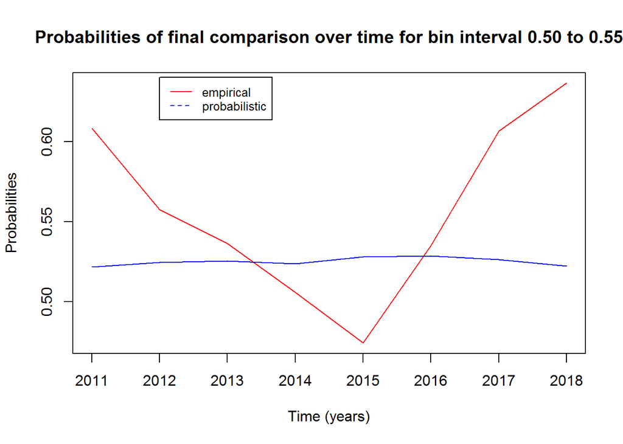

```r
#bin = 0.50 to 0.55  -  final

merged_matches_50_55_final=merged_matches_pinnacle_final[odd_cut_over=="(0.5,0.55]"]
merged_matches_50_55_final=merged_matches_50_55_final[,list(empirical_over=mean(IsOver),
                                                            probabilistic_over=mean(probOver),.N),by=list(Year)]
merged_matches_50_55_final=merged_matches_50_55_final[order(Year)]

plot(merged_matches_50_55_final$Year,merged_matches_50_55_final$empirical_over,type = "l",col="red",xlab="Time (years)",ylab="Probabilities"
     ,main='Probabilities of final comparison over time for bin interval 0.50 to 0.55')
lines(merged_matches_50_55_final$Year,merged_matches_50_55_final$probabilistic_over,col="blue")
legend(2012,0.64, legend=c("empirical", "probabilistic"), col=c("red", "blue"), lty=1:2, cex=0.8)
```

It can be seen that, for the bin interval of 0.55 to 0.60 of initial odds comparison, probabilities stay constant around the value of 0.57 to 0.60 while the empirical data fluctuates between 0.44 and 0.70. Expected probabilities are smoother than real results. There are empirical values both above and below the probabilistic values, and they are smoother compared to other bin intervals, except the for the year of 2016.

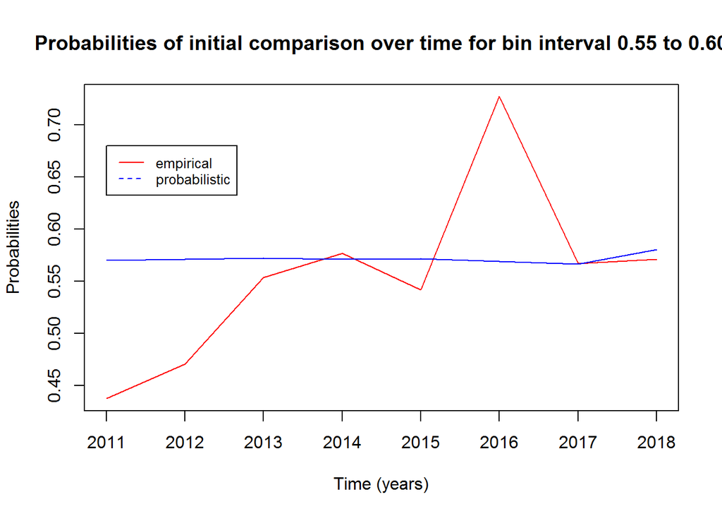

```r
#bin = 0.55 to 0.60  -  initial

merged_matches_55_60_initial=merged_matches_pinnacle_initial[odd_cut_over=="(0.55,0.6]"]
merged_matches_55_60_initial=merged_matches_55_60_initial[,list(empirical_over=mean(IsOver),
                                                                probabilistic_over=mean(probOver),.N),by=list(Year)]
merged_matches_55_60_initial=merged_matches_55_60_initial[order(Year)]

plot(merged_matches_55_60_initial$Year,merged_matches_55_60_initial$empirical_over,type = "l",col="red",xlab="Time (years)",ylab="Probabilities"
     ,main='Probabilities of initial comparison over time for bin interval 0.55 to 0.60')
lines(merged_matches_55_60_initial$Year,merged_matches_55_60_initial$probabilistic_over,col="blue")
legend(2011,0.68, legend=c("empirical", "probabilistic"), col=c("red", "blue"), lty=1:2, cex=0.8)
```

It can be seen that, for the bin interval of 0.55 to 0.60 of final odds comparison, probabilities stay constant around the value of 0.57 to 0.60 while the empirical data fluctuates between 0.46 and 0.70. Expected probabilities are smoother than real results. There are empirical values both above and below the probabilistic values, and they are smoother compared to other bin intervals, except the for the year of 2016. The probability for the year of 2014 got away from the empirical data with time.

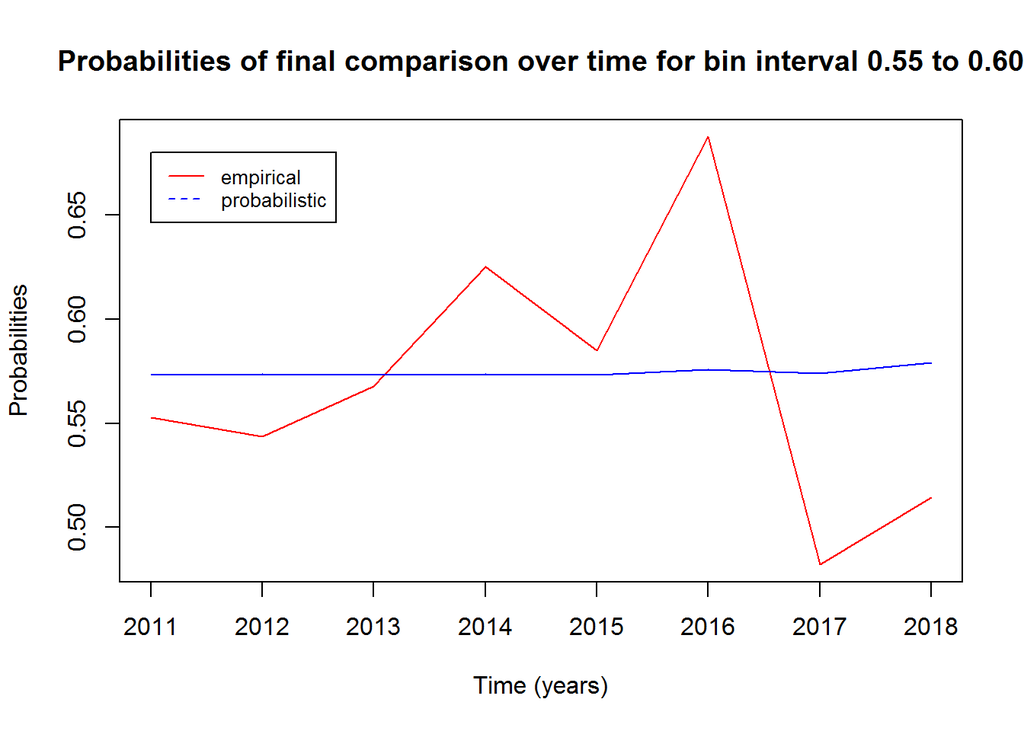

```r
#bin = 0.55 to 0.60  -  final

merged_matches_55_60_final=merged_matches_pinnacle_final[odd_cut_over=="(0.55,0.6]"]
merged_matches_55_60_final=merged_matches_55_60_final[,list(empirical_over=mean(IsOver),
                                                            probabilistic_over=mean(probOver),.N),by=list(Year)]
merged_matches_55_60_final=merged_matches_55_60_final[order(Year)]

plot(merged_matches_55_60_final$Year,merged_matches_55_60_final$empirical_over,type = "l",col="red",xlab="Time (years)",ylab="Probabilities"
     ,main='Probabilities of final comparison over time for bin interval 0.55 to 0.60')
lines(merged_matches_55_60_final$Year,merged_matches_55_60_final$probabilistic_over,col="blue")
legend(2011,0.68, legend=c("empirical", "probabilistic"), col=c("red", "blue"), lty=1:2, cex=0.8)
```

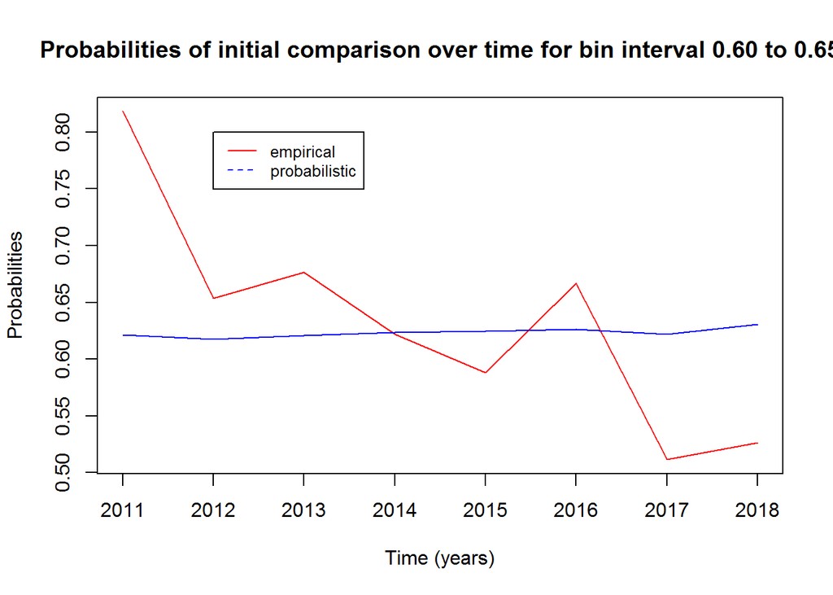

```r
#bin = 0.60 to 0.65  -  initial

merged_matches_60_65_initial=merged_matches_pinnacle_initial[odd_cut_over=="(0.6,0.65]"]
merged_matches_60_65_initial=merged_matches_60_65_initial[,list(empirical_over=mean(IsOver),
                                                                probabilistic_over=mean(probOver),.N),by=list(Year)]
merged_matches_60_65_initial=merged_matches_60_65_initial[order(Year)]

plot(merged_matches_60_65_initial$Year,merged_matches_60_65_initial$empirical_over,type = "l",col="red",xlab="Time (years)",ylab="Probabilities"
     ,main='Probabilities of initial comparison over time for bin interval 0.60 to 0.65')
lines(merged_matches_60_65_initial$Year,merged_matches_60_65_initial$probabilistic_over,col="blue")
legend(2012,0.80, legend=c("empirical", "probabilistic"), col=c("red", "blue"), lty=1:2, cex=0.8)
```

It can be seen that, for the bin interval of 0.6 to 0.65 of final odds comparison, probabilities stay constant around the value of 0.62 while the empirical data fluctuates between 0.56 and 0.70. Expected probabilities are smoother than real results. There are empirical values both above and below the probabilistic values and they are still more homogeneous compared to previous bin intervals even though time changed. The graph seems like empirical line got far away from probabilistic line but it can be seen that it actually got closer when the scale of y axis is checked.

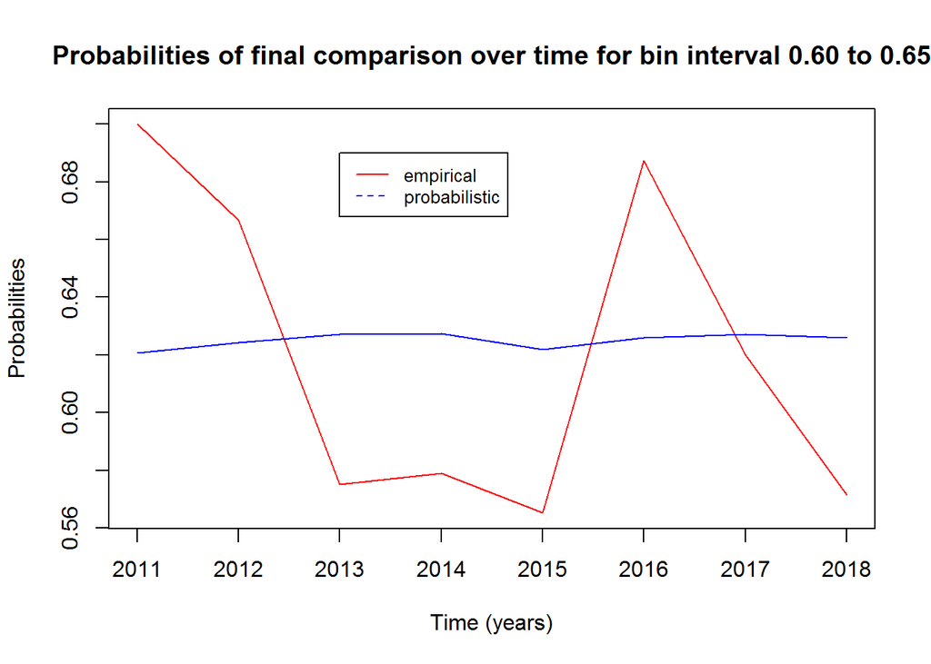

```r
#bin = 0.60 to 0.65  -  final

merged_matches_60_65_final=merged_matches_pinnacle_final[odd_cut_over=="(0.6,0.65]"]
merged_matches_60_65_final=merged_matches_60_65_final[,list(empirical_over=mean(IsOver),
                                                            probabilistic_over=mean(probOver),.N),by=list(Year)]
merged_matches_60_65_final=merged_matches_60_65_final[order(Year)]

plot(merged_matches_60_65_final$Year,merged_matches_60_65_final$empirical_over,type = "l",col="red",xlab="Time (years)",ylab="Probabilities"
     ,main='Probabilities of final comparison over time for bin interval 0.60 to 0.65')
lines(merged_matches_60_65_final$Year,merged_matches_60_65_final$probabilistic_over,col="blue")
legend(2013,0.69, legend=c("empirical", "probabilistic"), col=c("red", "blue"), lty=1:2, cex=0.8)
```

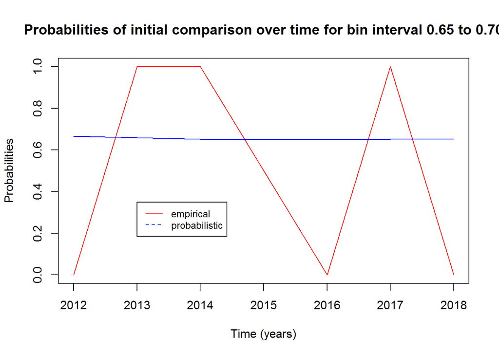

```r
#bin = 0.65 to 0.70  -  initial

merged_matches_65_70_initial=merged_matches_pinnacle_initial[odd_cut_over=="(0.65,0.7]"]
merged_matches_65_70_initial=merged_matches_65_70_initial[,list(empirical_over=mean(IsOver),
                                                                probabilistic_over=mean(probOver),.N),by=list(Year)]
merged_matches_65_70_initial=merged_matches_65_70_initial[order(Year)]

plot(merged_matches_65_70_initial$Year,merged_matches_65_70_initial$empirical_over,type = "l",col="red",xlab="Time (years)",ylab="Probabilities"
     ,main='Probabilities of initial comparison over time for bin interval 0.65 to 0.70')
lines(merged_matches_65_70_initial$Year,merged_matches_65_70_initial$probabilistic_over,col="blue")
legend(2013,0.35, legend=c("empirical", "probabilistic"), col=c("red", "blue"), lty=1:2, cex=0.8)
```

It can be seen that, for the bin interval of 0.65 to 0.70 of final odds comparison, probabilities stay constant around the value of 0.65 while the empirical data fluctuates between 0.5 and 1.0. Expected probabilities are smoother than real results. There were empirical values both above and below the probabilistic values initially, and in final time, it can be seen that the empirical values are much smoother compared to initial time, which shows a possible effect of time on probabilities.

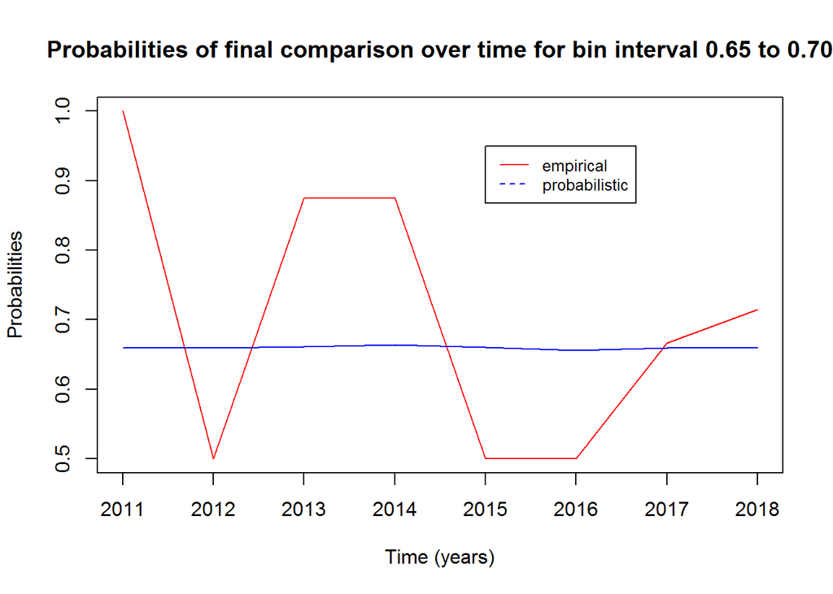

```r
#bin = 0.65 to 0.70  -  final

merged_matches_65_70_final=merged_matches_pinnacle_final[odd_cut_over=="(0.65,0.7]"]
merged_matches_65_70_final=merged_matches_65_70_final[,list(empirical_over=mean(IsOver),
                                                            probabilistic_over=mean(probOver),.N),by=list(Year)]
merged_matches_65_70_final=merged_matches_65_70_final[order(Year)]

plot(merged_matches_65_70_final$Year,merged_matches_65_70_final$empirical_over,type = "l",col="red",xlab="Time (years)",ylab="Probabilities"
     ,main='Probabilities of final comparison over time for bin interval 0.65 to 0.70')
lines(merged_matches_65_70_final$Year,merged_matches_65_70_final$probabilistic_over,col="blue")
legend(2015,0.95, legend=c("empirical", "probabilistic"), col=c("red", "blue"), lty=1:2, cex=0.8)
```

The pinnacle bookmaker is generally good at deciding over/under bins. And comparison between empirical data line and probabilistic data line over years with time effect on different bins can be seen in the previous graphs.